# Assignment-1

Nishant Ahlawat

2025-09-23

## I completed 15/15 tasks

# Task 1

```r
grading <- data.frame(
  Group = c("Labs", "Chapter Quizzes", "Assignments", "Projects",
            "In class Quizzes", "Midterm exams", "Final exam"),
  Count = c("16", "9", "4", "2", "TBD", "1", "1"),
  `Weight (each)` = c("0.625%", "0.56%", "3.75%", "3.33%, 6.67%", "-", "20%", "30%"),
  `Total Weight`  = c("10%", "5%", "15%", "10%", "10%", "20%", "30%"),
  check.names = FALSE
)

grading |>
  gt() |>
  tab_header(
    title = md("**Overall summary of the grading for this course**")
  ) |>
  cols_align(align = "left", columns = "Group") |>
  cols_align(align = "center", columns = c("Count", "Weight (each)", "Total Weight")) |>
  tab_options(
    table.font.names = "Courier",         # monospaced vibe
    data_row.padding = px(6),
    table.border.top.width = px(1),
    table.border.bottom.width = px(1)
  ) |>
  tab_source_note(md("_And, true to form, the right column sums to 100%!_")) |>
  tab_source_note(md(
    "There will be no curves in this course. A final grade in the 90s earns an **A**, \
a final grade in the 80s earns a **B**, a final grade in the 60s or 70s earns a **C**, \
a final grade in the 50s earns a **D**, and anything below 50 earns an **F**."
  ))
```

**Overall summary of the grading for this course**

| Group | Count | Weight (each) | Total Weight |
| --- | --- | --- | --- |
| Labs | 16 | 0.625% | 10% |
| Chapter Quizzes | 9 | 0.56% | 5% |
| Assignments | 4 | 3.75% | 15% |
| Projects | 2 | 3.33%, 6.67% | 10% |
| In class Quizzes | TBD | - | 10% |
| Midterm exams | 1 | 20% | 20% |
| Final exam | 1 | 30% | 30% |

*And, true to form, the right column sums to 100%!*  
There will be no curves in this course. A final grade in the 90s earns an **A**, a final grade in the 80s earns a **B**, a final grade in the 60s or 70s earns a **C**, a final grade in the 50s earns a **D**, and anything below 50 earns an **F**.

# Task 2

## (a)

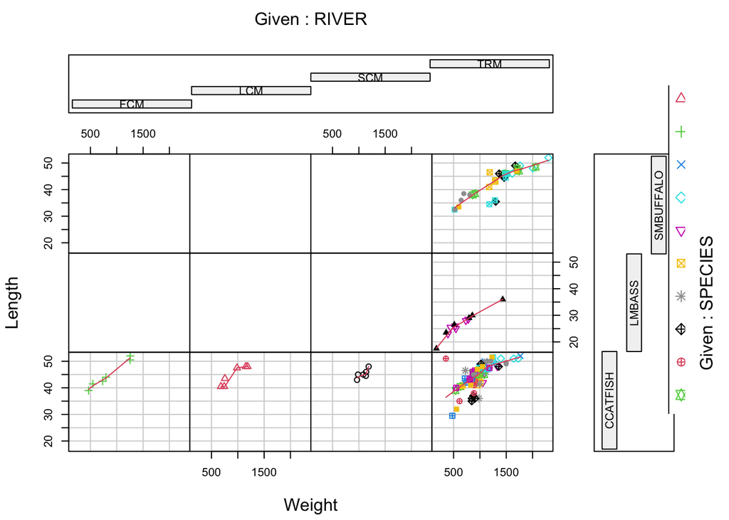

```r
ddt <- read.csv("DDT.csv")

# Treat MILE as factor
m <- with(ddt, as.numeric(factor(MILE)))

# Coplot LENGTH vs WEIGHT given RIVER*SPECIES
coplot(LENGTH ~ WEIGHT | RIVER * SPECIES,
       data = ddt,
       pch = m,                     # different plotting symbols
       col = m,                     # different colors
       panel = panel.smooth,        # adds smooth line
       xlab = "Weight", ylab = "Length")

legend("topright",
       legend = levels(factor(ddt$MILE)),
       col = 1:length(unique(m)),
       pch = 1:length(unique(m)),
       title = "MILE")
```

## (b) “The lower left panels correspond to the first RIVER-SPECIES combinations. They show positive association between LENGTH and WEIGHT: larger fish weigh more.

## (c) what does line A do?

m = with(ddt, as.numeric(factor(MILE))) “This converts the factor MILE into numeric codes (1, 2, 3, …). Each unique MILE gets a number that we can use for plotting symbols (pch) and colors.”

## (d) What does line B do?

length(unique(m)) “This counts how many unique MILE categories exist. It ensures we know how many distinct colors/symbols are needed for plotting.”

## (e) Why are the top six plots empty?

“The coplot is conditioned on RIVER*SPECIES. If no fish were caught for some RIVER-SPECIES combinations in the dataset, those panels have no data → they appear empty.”

## (f)

```r
mean_ddt <- mean(ddt$DDT[ddt$RIVER == "FCM" & ddt$SPECIES == "CCATFISH"])
mean_ddt
```

```
## [1] 45
```

# Task 3

“All highway bridges in the United States are inspected periodically for structural deficiency by the FHWA. Several variables from the National Bridge Inventory are given below. Classify each as **quantitative** or **qualitative**.”

| Variable | Type |
| --- | --- |
| a. Length of maximum span (feet) | Quantitative |
| b. Number of vehicle lanes | Quantitative |
| c. Toll bridge (yes or no) | Qualitative |
| d. Average daily traffic | Quantitative |
| e. Condition of deck (good, fair, or poor) | Qualitative (ordinal) |
| f. Bypass or detour length (miles) | Quantitative |
| g. Route type (interstate, U.S., state, county, or city) | Qualitative (nominal) |

## Notes

- **Quantitative**: numeric and measurable (continuous or discrete).
- **Qualitative**: categorical.
  - **Ordinal**: categories have a natural order (e.g., good > fair > poor).
  - **Nominal**: categories have no inherent order (e.g., route type).

# Task 4- Random Sampling Designs

## (a) The four random sampling designs are:

1. Simple random sampling
2. Stratified random sampling
3. Cluster sampling
4. Systematic sampling

## (b) **Descriptions of each sampling design**

- **Simple random sampling**:  
  Every experimental unit in the population has an equal chance of being selected. For example, drawing names from a hat or using a random number generator.
- **Stratified random sampling**:  
  The population is divided into groups (called strata) that are internally homogeneous (similar within each group) but different from one another. A random sample is then taken from each stratum, ensuring representation across all strata.
- **Cluster sampling**:  
  The population is divided into large groups (clusters) that mirror the overall population. A random sample of entire clusters is selected, and then all experimental units within the chosen clusters are observed.
- **Systematic sampling**:  
  A starting point is chosen at random, and then every *k*th experimental unit is selected from a list or sequence. For example, surveying every 10th person on a list.

# Task 5

We have data on 223 New Hampshire wells (`MTBE.csv`). The task is to select a random sample of 5 wells and answer follow-up questions.

## Random sample of 5 wells

```r
# Load libraries
library(knitr)
# Load data
mtbe <- read.csv("MTBE.csv", header = TRUE)

# First six rows (preview of dataset)
kable(head(mtbe), caption = "First six rows of MTBE data")
```

First six rows of MTBE data

| pH | SpConduct | DissOxy | RoadsPct | IndPct | UrbanPct | DevPct | WellClass | Aquifier | Depth | SafeYld | Distance | MTBE.Detect | MTBE.Level | HouseDen | PopDen |
| --- | --- | --- | --- | --- | --- | --- | --- | --- | --- | --- | --- | --- | --- | --- | --- |
| 7.87 | 290.0 | 0.58 | 1.34 | 0 | 17.77 | 17.77 | Private | Bedrock | 60.960 | NA | 2386.29 | Below Limit | 0.2 | 131.16 | 43.19 |
| 8.63 | 225.9 | 0.84 | 0.72 | 0 | 10.43 | 10.43 | Private | Bedrock | 36.576 | NA | 3667.69 | Below Limit | 0.2 | 47.69 | 24.52 |
| 7.11 | 157.4 | 8.37 | 1.92 | 0 | 29.62 | 50.01 | Private | Bedrock | 152.400 | NA | 2324.15 | Below Limit | 0.2 | 85.16 | 33.32 |
| 7.98 | 723.6 | 0.41 | 2.76 | 0 | 41.65 | 41.65 | Private | Bedrock | NA | NA | 788.88 | Below Limit | 0.2 | 134.77 | 46.61 |
| 7.88 | 148.7 | 1.44 | 3.51 | 0 | 51.21 | 51.21 | Private | Bedrock | 91.440 | NA | 1337.88 | Below Limit | 0.2 | 198.54 | 78.58 |
| 8.36 | 198.2 | 0.18 | 1.48 | 0 | 22.49 | 29.19 | Private | Bedrock | 115.824 | NA | 2396.74 | Below Limit | 0.2 | 206.73 | 59.47 |

```r
# Dimensions (rows and columns)
dim(mtbe)
```

```
## [1] 223  16
```

```r
# Select random indices
set.seed(123)   # for reproducibility
ind <- sample(1:223, 5, replace = FALSE)

# Random sample of 5 wells
sample_wells <- mtbe[ind, ]
kable(sample_wells, caption = "Random sample of 5 wells")
```

Random sample of 5 wells

|  | pH | SpConduct | DissOxy | RoadsPct | IndPct | UrbanPct | DevPct | WellClass | Aquifier | Depth | SafeYld | Distance | MTBE.Detect | MTBE.Level | HouseDen | PopDen |
| --- | --- | --- | --- | --- | --- | --- | --- | --- | --- | --- | --- | --- | --- | --- | --- | --- |
| 159 | 8.38 | 562.7 | 0.55 | 2.00 | 0.00 | 30.74 | 36.45 | Public | Bedrock | 48.768 | 83.27025 | 2270.32 | Below Limit | 0.20 | 158.45 | 72.98 |
| 207 | 7.62 | 579.6 | 2.57 | 2.50 | 0.00 | 25.85 | 32.34 | Public | Bedrock | 45.720 | NA | 1307.40 | Detect | 0.37 | 136.41 | 0.00 |
| 179 | 6.58 | 577.2 | 3.19 | 1.45 | 11.47 | 17.08 | 17.99 | Public | Bedrock | 76.200 | 37.85011 | 1193.43 | Below Limit | 0.20 | 63.03 | 21.01 |
| 14 | 6.39 | 95.1 | 1.82 | 0.79 | 0.00 | 7.80 | 7.80 | Private | Bedrock | 76.200 | NA | 1402.41 | Below Limit | 0.20 | 20.54 | 8.50 |
| 195 | 7.53 | 447.6 | 0.32 | 2.72 | 18.79 | 40.13 | 40.13 | Public | Bedrock | 121.920 | 18.92506 | 65.93 | Detect | 15.61 | 150.51 | 56.71 |

```r
## (i) Remove rows with missing values
# Remove rows with NA values
mtbeo <- na.omit(mtbe)

# Show cleaned dataset dimensions
dim(mtbeo)
```

```
## [1] 95 16
```

```r
# Show first few cleaned rows
kable(head(mtbeo), caption = "First rows of MTBE data with NAs removed")
```

First rows of MTBE data with NAs removed

|  | pH | SpConduct | DissOxy | RoadsPct | IndPct | UrbanPct | DevPct | WellClass | Aquifier | Depth | SafeYld | Distance | MTBE.Detect | MTBE.Level | HouseDen | PopDen |
| --- | --- | --- | --- | --- | --- | --- | --- | --- | --- | --- | --- | --- | --- | --- | --- | --- |
| 104 | 7.43 | 663.2 | 0.56 | 2.26 | 0.00 | 27.42 | 27.42 | Public | Unconsoli | 15.2400 | 1514.0045 | 1142.56 | Detect | 0.25 | 17.71 | 7.38 |
| 105 | 7.76 | 919.3 | 6.63 | 10.62 | 22.41 | 72.02 | 72.71 | Public | Unconsoli | 15.2400 | 1324.7540 | 274.61 | Below Limit | 0.20 | 132.22 | 46.20 |
| 106 | 7.01 | 409.9 | 5.94 | 1.58 | 0.84 | 20.88 | 20.88 | Public | Unconsoli | 19.2024 | 1052.2332 | 775.40 | Below Limit | 0.20 | 92.24 | 33.89 |
| 107 | 6.55 | 248.6 | 7.07 | 2.09 | 1.34 | 40.59 | 49.97 | Public | Unconsoli | 15.2400 | 946.2528 | 685.17 | Below Limit | 0.20 | 375.34 | 114.84 |
| 108 | 7.91 | 223.0 | 10.60 | 4.10 | 6.54 | 43.08 | 43.08 | Public | Unconsoli | 14.6304 | 946.2528 | 3192.79 | Below Limit | 0.20 | 77.01 | 34.23 |
| 109 | 7.51 | 428.5 | 7.94 | 1.95 | 0.00 | 35.42 | 51.90 | Public | Unconsoli | 24.9936 | 946.2528 | 2440.35 | Detect | 1.06 | 146.11 | 52.56 |

```r
## (ii) Standard deviation of depth for wells with Bedrock aquifer
# Subset wells where Aquifier == "Bedrock"
depth <- mtbeo[mtbeo$Aquifier == "Bedrock", ]$Depth

# Compute standard deviation
sd_depth <- sd(depth, na.rm = TRUE)
sd_depth
```

```
## [1] 56.45357
```

# Task 6

The U.S. Geological Survey recorded 2,929 aftershocks in the Los Angeles area following a major earthquake. The data (measured on the Richter scale) are in the file `EARTHQUAKE.csv`. We want to:

1. Select a random sample of 30 aftershocks.
2. Plot the magnitudes as a time series.
3. Compute the median magnitude for the full dataset.

## Random sample of 30 aftershocks

```r
# Load libraries
library(knitr)

# Load dataset
eq <- read.csv("EARTHQUAKE.csv", header = TRUE)

# First rows preview
kable(head(eq), caption = "First six rows of Earthquake data")
```

First six rows of Earthquake data

| YEAR | MONTH | DAY | HOUR | MINUTE | MAGNITUDE |
| --- | --- | --- | --- | --- | --- |
| 1994 | 1 | 17 | 12 | 30 | 6.7 |
| 1994 | 1 | 17 | 12 | 31 | 5.5 |
| 1994 | 1 | 17 | 12 | 32 | 3.3 |
| 1994 | 1 | 17 | 12 | 34 | 4.2 |
| 1994 | 1 | 17 | 12 | 36 | 3.8 |
| 1994 | 1 | 17 | 12 | 37 | 3.7 |

```r
# Dataset dimensions
dim(eq)
```

```
## [1] 2929    6
```

```r
# Select a random sample of 30 aftershocks
set.seed(123)  # reproducibility
ind <- sample(1:nrow(eq), 30, replace = FALSE)
sample_eq <- eq[ind, ]

# Show sample in a clean table
kable(sample_eq, caption = "Random sample of 30 aftershocks")
```

Random sample of 30 aftershocks

|  | YEAR | MONTH | DAY | HOUR | MINUTE | MAGNITUDE |
| --- | --- | --- | --- | --- | --- | --- |
| 2463 | 1994 | 2 | 1 | 20 | 51 | 2.0 |
| 2511 | 1994 | 2 | 2 | 9 | 1 | 1.3 |
| 2227 | 1994 | 1 | 29 | 6 | 18 | 1.8 |
| 526 | 1994 | 1 | 19 | 20 | 23 | 2.2 |
| 195 | 1994 | 1 | 18 | 0 | 32 | 2.6 |
| 1842 | 1994 | 1 | 26 | 11 | 42 | 2.1 |
| 1142 | 1994 | 1 | 22 | 13 | 12 | 1.5 |
| 1253 | 1994 | 1 | 23 | 1 | 24 | 1.9 |
| 1268 | 1994 | 1 | 23 | 3 | 9 | 1.9 |
| 1038 | 1994 | 1 | 22 | 0 | 14 | 2.1 |
| 665 | 1994 | 1 | 20 | 10 | 10 | 2.1 |
| 2650 | 1994 | 2 | 3 | 13 | 16 | 1.6 |
| 1627 | 1994 | 1 | 25 | 6 | 16 | 1.7 |
| 2757 | 1994 | 2 | 4 | 14 | 10 | 1.8 |
| 1011 | 1994 | 1 | 21 | 21 | 2 | 3.1 |
| 1115 | 1994 | 1 | 22 | 10 | 1 | 2.2 |
| 953 | 1994 | 1 | 21 | 15 | 14 | 1.6 |
| 348 | 1994 | 1 | 18 | 22 | 36 | 2.2 |
| 1017 | 1994 | 1 | 21 | 21 | 45 | 1.9 |
| 2013 | 1994 | 1 | 27 | 14 | 47 | 2.2 |
| 1379 | 1994 | 1 | 23 | 18 | 42 | 1.7 |
| 2888 | 1994 | 2 | 5 | 18 | 49 | 1.5 |
| 2074 | 1994 | 1 | 28 | 2 | 27 | 1.7 |
| 2567 | 1994 | 2 | 2 | 22 | 51 | 1.9 |
| 1450 | 1994 | 1 | 24 | 3 | 50 | 1.9 |
| 1673 | 1994 | 1 | 25 | 12 | 7 | 1.5 |
| 1790 | 1994 | 1 | 26 | 4 | 43 | 1.8 |
| 211 | 1994 | 1 | 18 | 2 | 20 | 2.7 |
| 1614 | 1994 | 1 | 25 | 3 | 36 | 1.5 |
| 2641 | 1994 | 2 | 3 | 11 | 38 | 1.9 |

## (i) Plot magnitudes as a time series

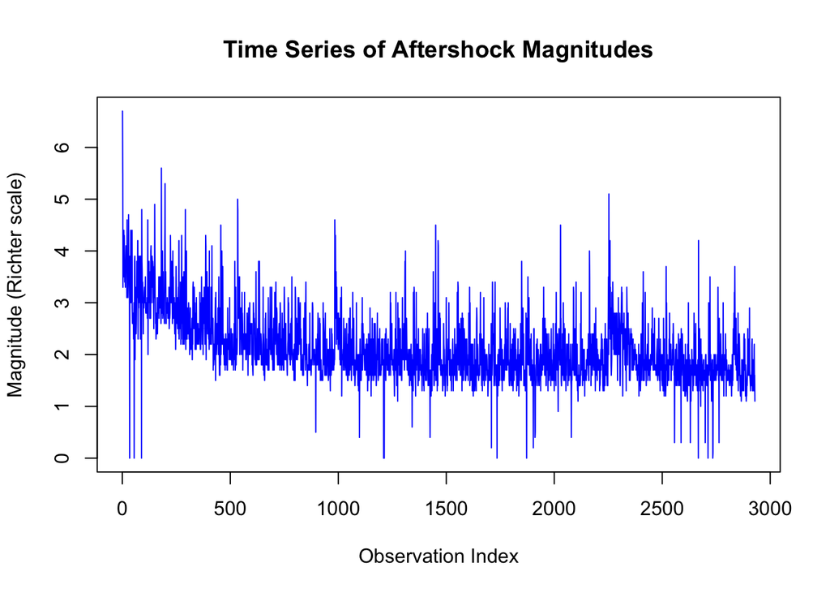

```r
# Time series plot of magnitudes
plot(ts(eq$MAG),
     main = "Time Series of Aftershock Magnitudes",
     ylab = "Magnitude (Richter scale)",
     xlab = "Observation Index",
     col = "blue")
```

## (ii) Median magnitude of all aftershocks

```r
median_mag <- median(eq$MAG, na.rm = TRUE)
median_mag
```

```
## [1] 2
```

# Task 7

## (a) What is the data collection method?

The data collection method is a **designed experiment**.  
Engineers collected fish specimens at predetermined river and tributary locations, measuring weight, length, and DDT concentration.

## (b) What is the population?

The population is **all fish in the Tennessee River and its tributaries**.  
The 144 fish captured and measured represent a **sample** from this larger population.

## (c) Give the names of all the qualitative variables.

The qualitative variables are:

- **River** (capture location: TR, FC, LC, SC)
- **Mile** (distance upstream, categorical in this study)
- **Species** (channel catfish, largemouth bass, smallmouth buffalo)

## Notes

- **Qualitative variables** describe categories or labels.
- **Quantitative variables** (not asked here, but present) include weight (g), length (cm), and DDT concentration (ppm).

# Task 8

## (a) What type of graph is used to describe the data?

A **bar graph** is used to describe the data.

## (b) What is the variable measured?

The variable measured is **type of robotic limbs** for each robot.

## (c) Which design is used the most?

The **“Legs only”** design (63 robots) is the most common.

## (d) Compute class relative frequencies

```r
# Frequencies of robot limb categories
freq <- c(15, 8, 63, 20)
RL <- c("None", "Both", "Legs only", "Wheels only")

# Data frame
robots <- data.frame(Category = RL, Frequency = freq)

# Total sample size
n <- sum(freq)

# Relative frequencies
robots$RelativeFreq <- round(robots$Frequency / n, 4)

robots
```

```
##      Category Frequency RelativeFreq
## 1        None        15       0.1415
## 2        Both         8       0.0755
## 3   Legs only        63       0.5943
## 4 Wheels only        20       0.1887
```

```r
knitr::kable(robots, digits = 3, caption = "Frequencies and Relative Frequencies of Robot Designs")
```

Frequencies and Relative Frequencies of Robot Designs

| Category | Frequency | RelativeFreq |
| --- | --- | --- |
| None | 15 | 0.142 |
| Both | 8 | 0.076 |
| Legs only | 63 | 0.594 |
| Wheels only | 20 | 0.189 |

## (e) Pareto diagram

```r
library(qcc)
```

[figure not shown]

```
##
## Pareto chart analysis for freq
##     Frequency Cum.Freq. Percentage Cum.Percent.
##   C  63.00000  63.00000   59.43396     59.43396
##   D  20.00000  83.00000   18.86792     78.30189
##   A  15.00000  98.00000   14.15094     92.45283
##   B   8.00000 106.00000    7.54717    100.00000
```

```r
pareto.chart(freq,
             names = RL,
             main = "Pareto Diagram of Robotic Limb Categories",
             ylab = "Number of Robots")
```

# Task 9

Researchers analyzed 50 Microsoft security bulletins from 2012.  
- Windows: 32  
- Explorer: 6  
- Office: 12

Categories of security repercussions:  
- Denial of service = 6  
- Information disclosure = 8  
- Remote code execution = 22  
- Spoofing = 3  
- Privilege elevation = 11

## (a) Pie chart of Microsoft products with security issues

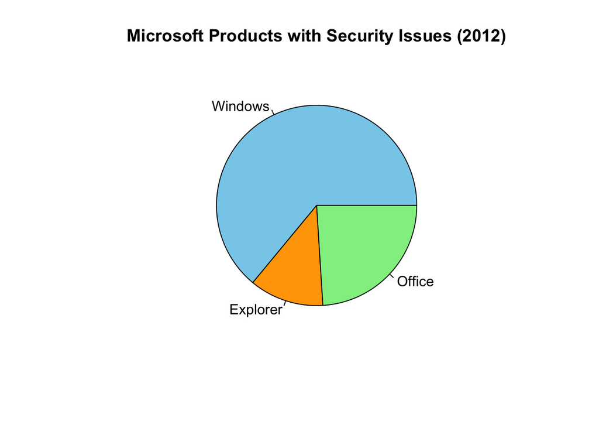

```r
products <- c("Windows", "Explorer", "Office")
counts <- c(32, 6, 12)

# Pie chart
pie(counts,
    labels = products,
    main = "Microsoft Products with Security Issues (2012)",
    col = c("skyblue", "orange", "lightgreen"))
```

## (b) Pareto diagram of repercussions

[figure not shown]

```
##
## Pareto chart analysis for freq
##     Frequency Cum.Freq. Percentage Cum.Percent.
##   C        22        22         44           44
##   E        11        33         22           66
##   B         8        41         16           82
##   A         6        47         12           94
##   D         3        50          6          100
```

```r
# Categories of repercussions
issues <- c("Denial of service", "Information disclosure",
            "Remote code execution", "Spoofing", "Privilege elevation")
freq <- c(6, 8, 22, 3, 11)

# If qcc not installed: install.packages("qcc")
library(qcc)

pareto.chart(freq,
             names = issues,
             main = "Pareto Chart of Security Issue Repercussions",
             ylab = "Number of Bulletins")
```

# Task 10

```r
# Load package
library(plotrix)

# Load data
swd <- read.csv("SWDEFECTS.csv", header = TRUE)

# Tabulate defects
tab <- table(swd$defect)
rtab <- tab / sum(tab)

# Relative frequencies
round(rtab, 2)
```

```
##
## FALSE  TRUE
##   0.9   0.1
```

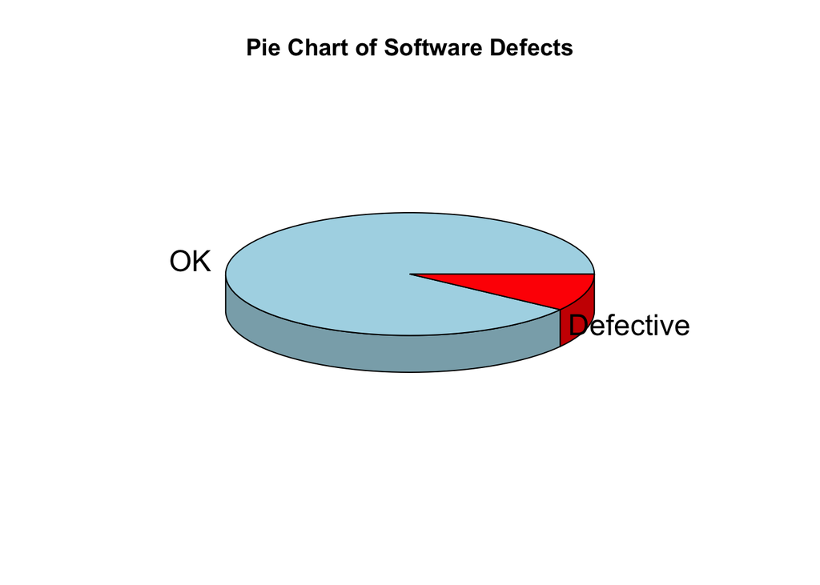

```r
# 3D pie chart
pie3D(rtab,
      labels = c("OK", "Defective"),
      main = "Pie Chart of Software Defects",
      col = c("lightblue", "red"))
```

# Task 11

## Data

```r
old <- c(9.98, 10.12, 9.84, 10.26, 10.05, 10.15, 10.05, 9.80, 10.02,
         10.29, 10.15, 9.80, 10.03, 10.00, 9.73, 8.05, 9.87, 10.01,
         10.55, 9.55, 9.98, 10.26, 9.95, 8.72, 9.97, 9.70, 8.80,
         9.87, 8.72, 9.84)

new <- c(9.19, 10.01, 8.82, 9.63, 8.82, 8.65, 10.10, 9.43, 8.51,
         9.70, 10.03, 9.14, 10.09, 9.85, 9.75, 9.60, 9.27, 8.78,
         10.05, 8.83, 9.35, 10.12, 9.39, 9.54, 9.49, 9.48, 9.36,
         9.37, 9.64, 8.68)
```

## (a) Relative frequency histogram – Old Location

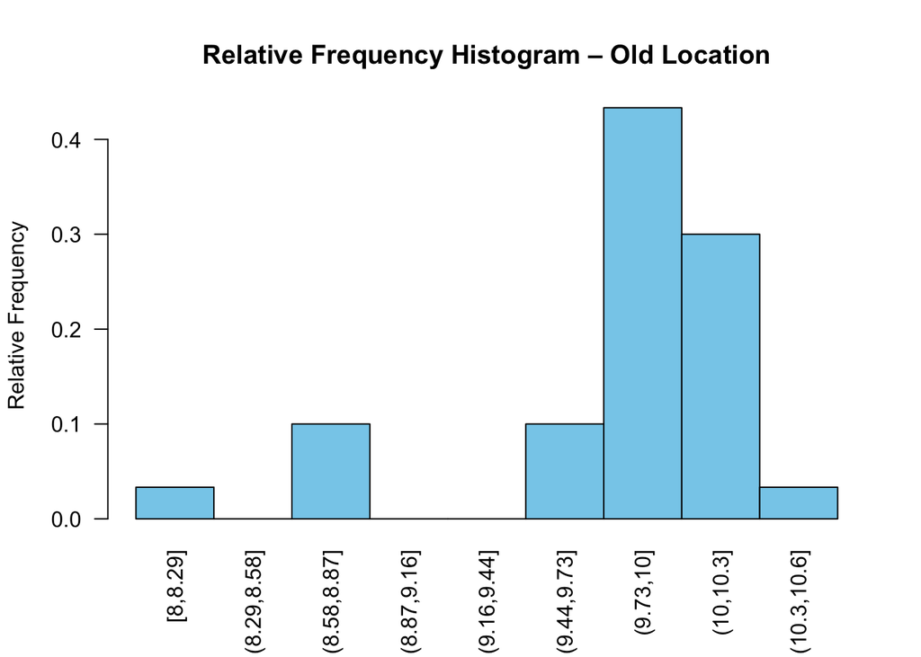

```r
# Define bins 8.0–10.6 with 9 classes

bins <- seq(8.0, 10.6, length.out = 10)

old_cut <- cut(old, breaks = bins, right = TRUE, include.lowest = TRUE)
old_tab <- table(old_cut)
old_rel <- old_tab / length(old)

barplot(old_rel, space = 0, col = "skyblue",
        main = "Relative Frequency Histogram – Old Location",
        ylab = "Relative Frequency", las = 2)
```

```r
old_rel
```

```
## old_cut
##    [8,8.29] (8.29,8.58] (8.58,8.87] (8.87,9.16] (9.16,9.44] (9.44,9.73]
##  0.03333333  0.00000000  0.10000000  0.00000000  0.00000000  0.10000000
##   (9.73,10]   (10,10.3] (10.3,10.6]
##  0.43333333  0.30000000  0.03333333
```

## (b) Stem-and-leaf display

```r
stem(old)
```

```
##
##   The decimal point is at the |
##
##    8 | 1
##    8 | 778
##    9 |
##    9 | 677888899
##   10 | 0000000011122333
##   10 | 6
```

## (c) Histogram (using barplot, not hist)

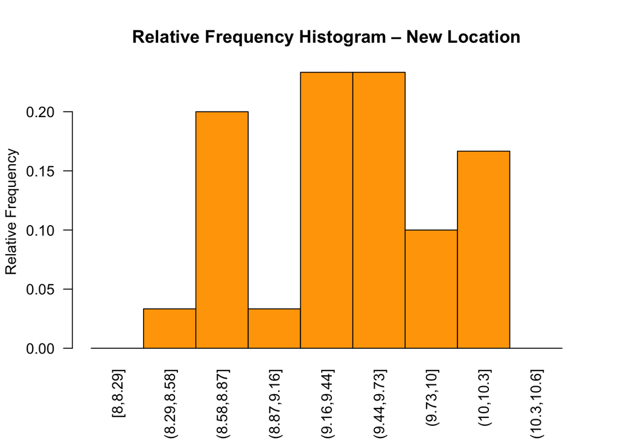

```r
new_cut <- cut(new, breaks = bins, right = TRUE, include.lowest = TRUE)
new_tab <- table(new_cut)
new_rel <- new_tab / length(new)

barplot(new_rel, space = 0, col = "orange",
        main = "Relative Frequency Histogram – New Location",
        ylab = "Relative Frequency", las = 2)
```

```r
new_rel
```

```
## new_cut
##    [8,8.29] (8.29,8.58] (8.58,8.87] (8.87,9.16] (9.16,9.44] (9.44,9.73]
##  0.00000000  0.03333333  0.20000000  0.03333333  0.23333333  0.23333333
##   (9.73,10]   (10,10.3] (10.3,10.6]
##  0.10000000  0.16666667  0.00000000
```